# Ch4P2 Visualization Basics Part II

Descriptive Analytics and Data Visualization

Yichen Qin (qinyn@ucmail.uc.edu), University of Cincinnati

2024-02-02

In this chapter, we continue to discuss the visualization basics. The following R packages are needed for running the examples in this chapter.

```r
library(tidyverse)
library(grid)
library(gridExtra)
library(RColorBrewer)
```

# 1 Barplot

So far we have focused on visualizing continuous variables through the example of scatter plots. In addition to continuous variables, discrete variables are also common in data analysis. In this section, we will focus on visualizing discrete variables. In this case, a barplot is the most frequently used tool.

For example, we could use the barplot to show the frequency/distribution of different categories and the composition of the discrete variable. In the college data set, suppose we are interested in the number of university in different regions in US, such as northeast, midwest, west, and south. Then we could use the barplot to visualize this information. The code below consists two parts. The first part transforms the original data to the counts of universities in each region using `group_by()` and `summarize()` functions. This is essentially the data wrangling step. The second part take the count data and plot it in the barplot using the geometry function `geom_col()`, which is the data visualization step. Note that it is always better to have meaningful x or y axis in the barplot. For example, we could sort all the bars according to the frequencies.

```r
college = read.csv("data/college.csv", header = TRUE)
region_freq = college %>%
  group_by(region) %>%
  summarise(count=n())
region_freq
```

```
## # A tibble: 4 x 2
##   region    count
##   <chr>     <int>
## 1 Midwest     353
## 2 Northeast   299
## 3 South       459
## 4 West        158
```

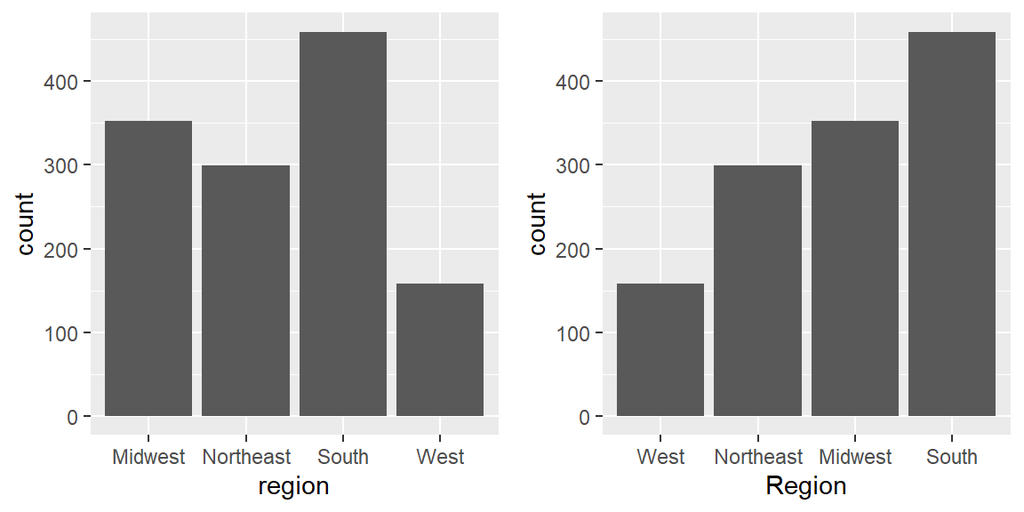

```r
g1 = ggplot(region_freq) +
  geom_col(aes(x = region, y = count))
g2 = college %>%
  group_by(region) %>%
  summarize(count=n()) %>%
  ggplot() +
  geom_col(aes(x = reorder(region, count),
               y = count)) +
  xlab("Region")
grid.arrange(g1, g2, ncol=2)
```

The code above first counts the number of universities in each region, and then plot their frequencies. Alternatively, we could manually calculate the frequencies ourselves and directly plot them. We will need to either set `stat="identity"` in `geom_bar()`, or use `geom_col()`. Note that ordering the axis is slightly different in `geom_col()` than in `geom_bar()`.

Meanwhile, in addition to `geom_col()`, `geom_bar()` is another option for generating the barplot. To directly plot the counts in `region_freq`, we could use `geom_bar(aes(xxx, yyy), stat="identity")`. In addition, `geom_bar()` can combines the data wrangling step with the data visualization step. To achieve this, we remove `stat="identity"` and directly plug the college data set into `ggplot()`. For details, please refer to the following code. Note that the code below all produce the same results.

```r
g1 = ggplot(region_freq) +
  geom_col(aes(y=region, x = count))
g2 = ggplot(region_freq) +
  geom_bar(aes(y=region, x = count), stat="identity")
g3 = ggplot(college) +
  geom_bar(aes(y=region)) + ylab("region")
grid.arrange(g1,g2,g3, ncol=3)
```

[output not shown]

The barplot not only can visualize the distribution of one discrete variable, but also the relationship between two or more discrete variables through its variations. For example, the argument `position` in `geom_bar()` function can adjust the position to show different graphical properties which includes “identity”, “dodge”, “fill”,and “stack”.

- “identity”: No adjustment. So it generates the traditional barplot.
- “dodge”: It splits each bar into multiple pieces and generates side-by-side bars.
- “fill”: It fills different colors within each bar and use bar lengths to represent proportions.
- “stack”: It adds different colors to one bar and generate stacked bars.

For the college data set example, suppose we want to visualize the association between the region of the university `region` and the funding type of the university, we can use the following barplots.

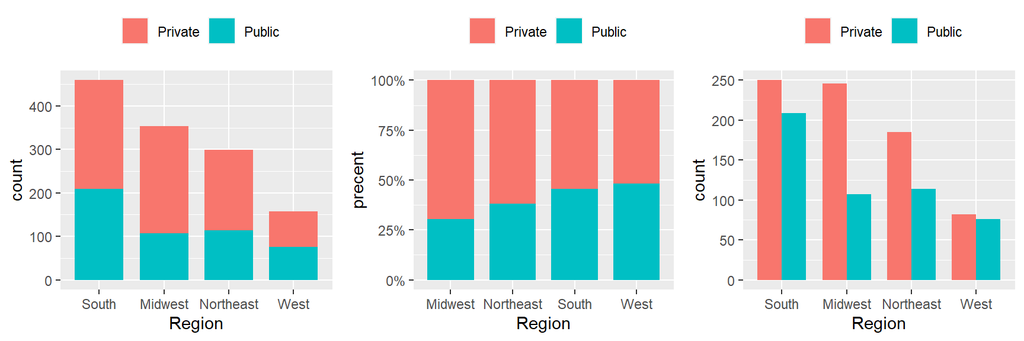

```r
g1=ggplot(data=college) +
  geom_bar(aes(x=fct_relevel(region, "South", "Midwest", "Northeast", "West"), fill = control),
           width=0.75) +
  scale_x_discrete(name = "Region") +
  scale_fill_discrete(name = "")+
  theme(legend.position = "top")
g2=ggplot(data=college) +
  geom_bar(aes(x=region, fill = control),
           position="fill",
           width = 0.75) +
  scale_x_discrete(name = "Region") +
  scale_fill_discrete("")+
  scale_y_continuous(name="precent", labels = scales::percent)+
  theme(legend.position = "top")
g3=ggplot(data=college) +
  geom_bar(aes(x=fct_relevel(region, "South", "Midwest", "Northeast", "West"), fill = control),
           position="dodge",
           width=0.75) +
  scale_x_discrete(name = "Region") +
  scale_fill_discrete("") +
  theme(legend.position = "top")
grid.arrange(g1,g2,g3,ncol=3)
```

If we want to avoid using dodge or stacked barplot, we could use facet visualization and plot barplots side by side.

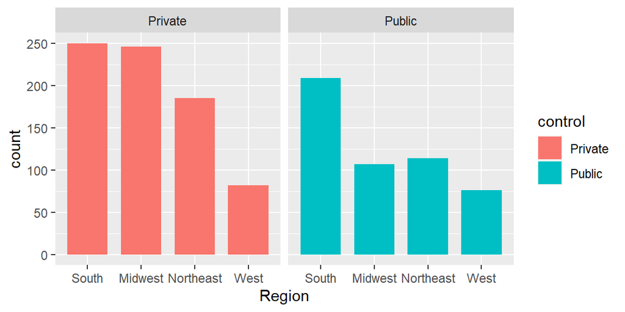

```r
ggplot(data=college) +
  geom_bar(aes(x=fct_relevel(region, "South", "Midwest", "Northeast", "West"),
               fill = control),
           width=0.75) +
  scale_x_discrete(name = "Region") +
  scale_y_continuous(limits = c(0, 250)) +
  facet_wrap(~control)
```

When visualizing the amount across different categories, barplot may not be the most suitable tool. Take a look at the following example. We plot the average SAT score in each state in US using a barplot. Note that we have sort the bars according to the SAT scores. The SAT score are mostly between 800 and 1400 (You get 400 by just putting your name down). When we take the average across all universities in each state, the variation in the SAT score for each state becomes even less. Therefore, we mostly see many long bars of similar lengths. The visualization is accurate, but not informative. We can emphasize on the difference of SAT score by changing the range of y-axis, which is the middle figure. However, the length of the bar is not proportional to SAT which violates one of the most important principal in data visualization. We will discuss this principal in details in the following chapter. For example, it seems that the SAT of North Carolina (NC) is about twice the SAT of West Virginia (WV) since the bar of the former is twice as long as the bar of latter. In this case, we can alternatively use dot plot, which is just scatter plot, but with one axis being discrete data. The dot only indicates the location of the data point.

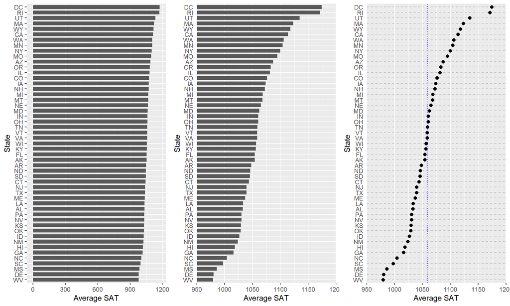

```r
state_sat_df = college %>%
  group_by(state) %>%
  summarize(state_sat = mean(sat_avg))
g1 = state_sat_df %>%
  ggplot() +
  geom_col(aes(y=fct_reorder(state, state_sat), x = state_sat), width = 0.7) +
  scale_y_discrete(name = "State") +
  xlab("Average SAT")
g2 = state_sat_df %>%
  ggplot() +
  geom_col(aes(y=fct_reorder(state, state_sat), x = state_sat), width = 0.7) +
  scale_y_discrete(name = "State") +
  coord_cartesian(xlim = c(950,1200) ) +
  scale_x_continuous(expand = c(0,0)) +
  xlab("Average SAT") +
  theme(axis.ticks.y = element_blank())
g3 = state_sat_df %>%
  ggplot() +
  geom_point(aes(y=fct_reorder(state, state_sat), x = state_sat), size = 2) +
  scale_y_discrete(name = "State") +
  coord_cartesian(xlim = c(950,1200) ) +
  scale_x_continuous(expand = c(0,0)) +
  xlab("Average SAT") +
  geom_vline(xintercept = mean(college$sat_avg),
             color = "blue",
             linetype = "dotted")+
  theme(axis.ticks.y = element_blank(),
        panel.grid.major.y = element_line(color = "grey",
                                          linetype = "dashed"))
grid.arrange(g1,g2,g3,ncol=3)
```

There are many variations of the barplot, for example, **population pyramid**. We use Saudi Arabia’s population data to generate the population pyramid as follows. As we can see, there are much more working age men in Saudi Arabia than women. This is because there are many immigrants coming to Saudi Arabia for work.

```r
saudi = read_csv("data/saudi_arabia.csv")
saudi
```

```
## # A tibble: 102 x 12
##    FIPS  GENC  `Country/Area Name`  Year GROUP Population `% of Population`
##    <chr> <chr> <chr>               <dbl> <chr>      <dbl>             <dbl>
##  1 SA    SA    Saudi Arabia         2023 TOTAL   35939806            100
##  2 SA    SA    Saudi Arabia         2023 0         494327              1.38
##  3 SA    SA    Saudi Arabia         2023 1         495889              1.38
##  4 SA    SA    Saudi Arabia         2023 2         502139              1.40
##  5 SA    SA    Saudi Arabia         2023 3         511583              1.42
##  6 SA    SA    Saudi Arabia         2023 4         522930              1.46
##  7 SA    SA    Saudi Arabia         2023 5         536550              1.49
##  8 SA    SA    Saudi Arabia         2023 6         551843              1.54
##  9 SA    SA    Saudi Arabia         2023 7         568419              1.58
## 10 SA    SA    Saudi Arabia         2023 8         584245              1.63
## # ... with 92 more rows, and 5 more variables: `Male Population` <dbl>,
## #   `% of Males` <dbl>, `Female Population` <dbl>, `% of Females` <dbl>,
## #   `Sex Ratio` <dbl>
```

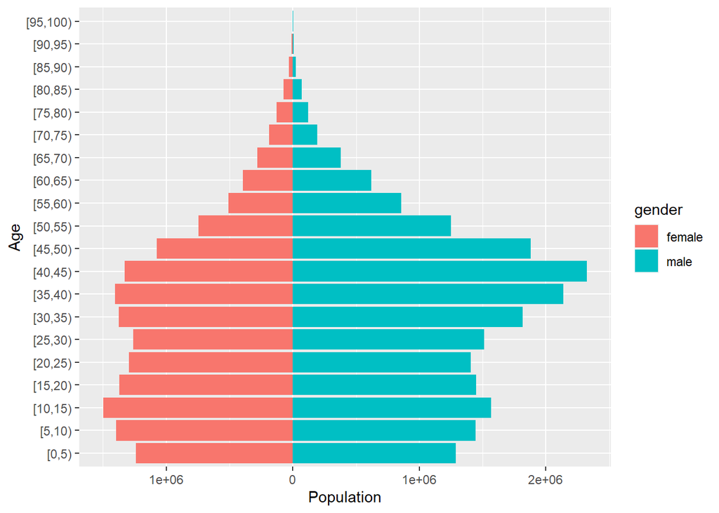

```r
saudi %>%
  select(GROUP, `Male Population`, `Female Population`) %>%
  rename(age = GROUP,
         male = `Male Population`,
         female = `Female Population`) %>%
  filter(age != c("TOTAL", "100+")) %>%
  mutate_at(c("age"), as.numeric) %>%
  mutate(age_group = cut(age, breaks = seq(0, 100, 5), right = FALSE)) %>%
  pivot_longer(cols = c("male", "female"),
               names_to = "gender",
               values_to = "pop") %>%
  ggplot() +
  geom_col(aes(y = age_group,
               x = ifelse(gender == "male", pop, -pop),
               fill = gender)) +
  scale_x_continuous(labels = abs) +
  xlab("Population") +
  ylab("Age")
```

The barplot can sometimes be confused with the histogram. However, they have different purposes and should be applied to different scenarios. The barplot visualizes the distribution of the discrete data, whereas the histogram visualizes the distribution of the continuous data. In the college data set, suppose we are interested in the distribution of the continuous variable SAT, then we could use histogram. Compared the histogram with the barplot at the beginning of this section, we can see that the bars are separated and the order of the bars can be customized since it is the discrete data. On the other hand, the bars in the histogram are adjacent to each other because each bar represents the frequency of the observations falling into the consecutive intervals.

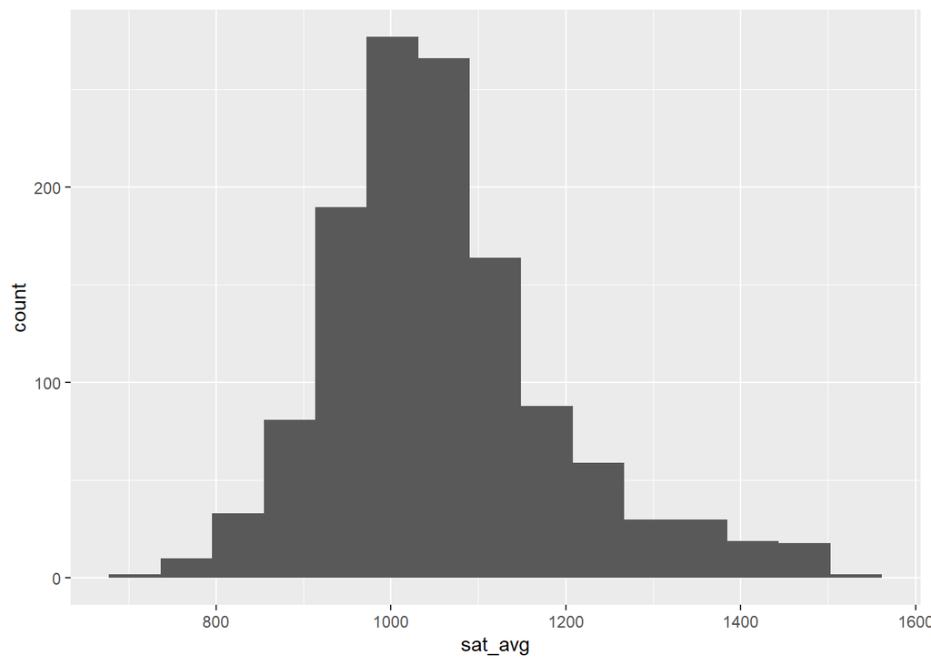

```r
ggplot(data = college, aes(x = sat_avg)) +
       geom_histogram(bins=15)
```

# 2 Pie/Donut Chart

We briefly discuss the pie chart, which is used to visualize the composition of a discrete variable. There are two forms for pie charts, the filled circle or colored ring. The pie chart uses the angel or the length of the curve to represent the proportion of each category or an unique value. Since these angels or curves are often in different orientations, the comparison across different categories are often difficult. This is also why we do not recommend pie chart. Instead, we should use the barplot which is more efficient.

Let us take a look at the example. Suppose we would like to compare on the number of universities in the five states in the midwest area, including OH, MI, IN, IL, and WI. We generate the pie chart, the ring chart, and the barplot for comparison. As we can see, other than OH which has the most of the universities, it is hard to compare the rest of the states as they angels and ring segments are almost the same. When looking the barplot, it is apparent that WI has the lowest number, while IL is higher than IN and IN is higher than MI. This insight cannot be easily obtained in the pie chart and donute chart, which is why we should avoid using them. There are some remedies for these charts, such as adding the percentage numbers next to the pie. But the visualization is meant to be self-explanatory, efficient and faithfully, adding the text is conflicting to these goals.

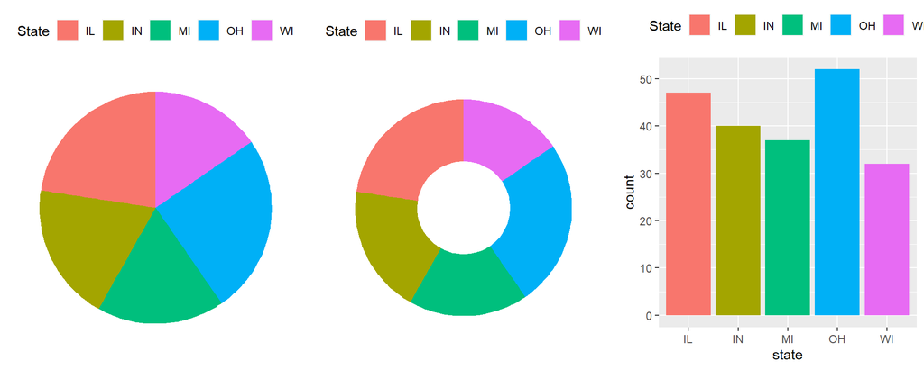

```r
g1 = ggplot(filter(college, state %in% c("OH", "MI", "IN", "IL", "WI")),
            aes(x = 1, fill = state)) +
  geom_bar() +
  scale_fill_discrete("State")+
  coord_polar(theta = "y") +
  theme(panel.background = element_blank(),
        axis.ticks = element_blank(),
        axis.text = element_blank(),
        axis.title = element_blank(),
        legend.position = "top")
g2=ggplot(filter(college, state %in% c("OH", "MI", "IN", "IL", "WI")),
          aes(x = 1, fill = state)) +
  geom_bar(width = 0.8) +
  scale_fill_discrete("State")+
  coord_polar(theta = "y") +
  scale_x_continuous(limits=c(0,1.5)) + # Add a continuous x scale from 0.5 to 1.5
  theme(panel.background = element_blank(),
        axis.ticks = element_blank(),
        axis.text = element_blank(),
        axis.title = element_blank(),
        legend.position = "top")
g3=ggplot(filter(college, state %in% c("OH", "MI", "IN", "IL", "WI")),
          aes(x = state, fill=state)) +
  scale_fill_discrete("State")+
  geom_bar() +
  theme(legend.position = "top")
grid.arrange(g1,g2,g3,ncol=3)
```

# 3 Colors

Color is an essential component of data visualization. So far, we have been using the default colors in `ggplot()`. In this section, we will discuss how to efficiently use colors to represent data.

Let us start with a few examples. We begin by illustrating the relationship between SAT scores and tuition fees for all private schools using a scatter plot, and use the sizes of the points to represent the number of students to create a bubble chart. If we want to specifically compare schools in California (CA), Tennessee (TN), and all other states, we can simply create a variable called “State” to indicate whether the school is located in California, Tennessee, or another state. We can then map this new variable to the color dimension of the graph, achieving the goal of using color for comparison (left graph). We can observe that schools in California generally have higher tuition fees, likely due to the higher cost of living on the West Coast. In contrast, Tennessee, being in the central region, has relatively lower tuition fees. Compared to all other states, California falls into the category of expensive tuition states, while Tennessee is among the states with lower tuition. Alternatively, if we want to display the admission rates for all these private schools, we can directly map the admission rate variable to the color dimension of the graph, accomplishing the goal of using color for comparison (right graph). We can see that as SAT scores increase, tuition fees also become more expensive, while admission rates gradually decrease. This phenomenon is understandable; as schools become more selective, the admitted students naturally have better academic performance. At the same time, such schools may charge higher tuition fees to provide a more comprehensive education.

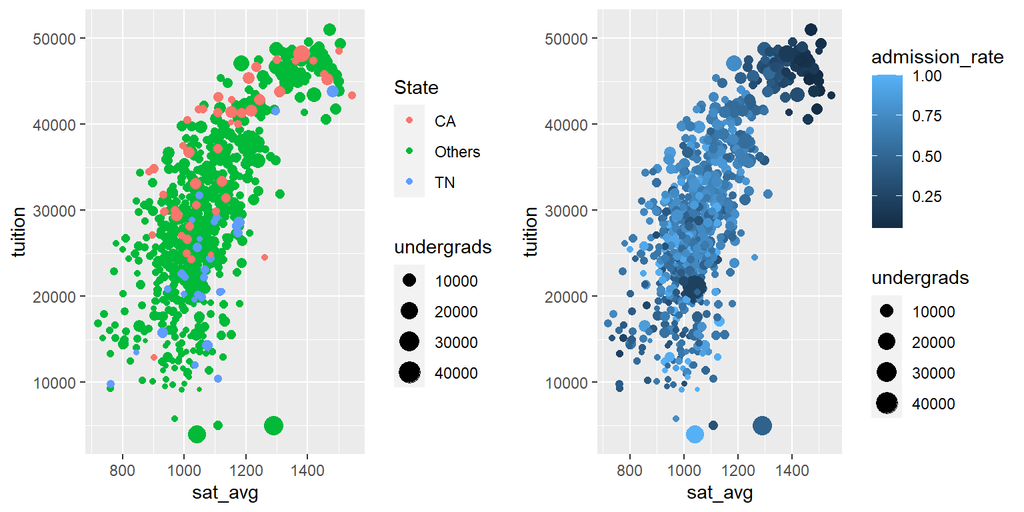

```r
g1 = college %>%
  filter(control == "Private") %>%
  mutate(State = ifelse(state == "CA", "CA", ifelse(state == "TN", "TN", "Others"))) %>%
  arrange(factor(State, levels=c("Others", "TN", "CA"))) %>%
  ggplot() +
  geom_point(aes(x = sat_avg, y = tuition, color = State, size = undergrads))
g2 = college %>%
  filter(control == "Private") %>%
  arrange(state=="CA") %>%
  ggplot() +
  geom_point(aes(x = sat_avg, y = tuition, color = admission_rate, size = undergrads))
grid.arrange(g1,g2,ncol=2)
```

The methods mentioned above for specifying colors are very simple and effective. We simply map a variable to the color dimension of the graph, and the specific color selection is automatically handled by `ggplot`. However, the power of color goes far beyond these basics. Now, let us delve into the specific application of color.

## 3.1 Color Coding

The colors in R can be mainly referenced/indexed in three ways: color names, 3-digit RGB values, and hexadecimal strings. Using these three methods, we can access thousands of colors.

For example, we can use color names, such as “red,” “orange,” “yellow,” “wheat,” and “salmon”, to represent colors. By using color names, we can access 657 built-in colors in R. The complete list of color names is provided by `colors()` function. Due to space constraints, we display only a small random sample of colors below. The complete list of these color names and the corresponding colors are given at http://www.stat.columbia.edu/~tzheng/files/Rcolor.pdf[^1].

```r
colors()[sample(1:length(colors()),20)]
```

```
##  [1] "grey50"         "slategrey"      "lightsalmon3"   "darkslategray3"
##  [5] "steelblue"      "beige"          "gray99"         "grey60"
##  [9] "gray29"         "lavenderblush4" "chartreuse"     "hotpink2"
## [13] "coral1"         "lemonchiffon3"  "grey55"         "gray55"
## [17] "gray75"         "lightsalmon1"   "brown3"         "cornsilk4"
```

Alternatively, we could refer each color by a three-dimensional numerical vector, called RGB value or RGB color. Each element in the vector is an integer number between 0 and 255, representing the proportion of red, green, and blue, respectively, in the color. For example, (255, 255, 255) represent white because it has highest proportion of red, green, and blue. Meanwhile, (255, 0, 0) represents red because it has no green and blue. To check the actual color for each RGB value, please use the website https://www.rapidtables.com/web/color/RGB_Color.html. Since each element is an integer between 0 and 255, there are in total `256*256*256=16,777,216` possible colors in the RGB color system. Compared to the color names, using RGB value is more powerful since we can use much more colors, but it also requires deeper understanding of the color system. Sometimes, the integer between 0 and 255 can be replaced by a numerical value between 0 and 1 where 1 correponds to 255. To reference colors using their RGB values, we use `rgb()`` function.

```r
rgb(255, 165, 0, maxColorValue = 255)
```

```
## [1] "#FFA500"
```

```r
rgb(1, 0.5, 0)
```

```
## [1] "#FF8000"
```

```r
rgb(1, 0.5, 0, alpha = 0.5) # alpha represents the transparency level.
```

```
## [1] "#FF800080"
```

Lastly, we could refer colors by their hexadecimal strings, e.g., “#FF0000”, “#FFA500”, “#FFFF00”. The string starts with `#`, and each following character represents a Hexadecimal is a base-16 number system used to describe color. Red, green, and blue are each represented by two characters (#rrggbb). Each character has 16 possible symbols: 0,1,2,3,4,5,6,7,8,9,A,B,C,D,E,F. For example, white RGB code is `rbg(255,255,255)` which can be represented as `#FFFFFF = 255*65536+255*256+255` and gray RGB code is `rgb(128,128,128)` which can be represented as `#808080 = 128*65536+128*256+128` and brow is `(165,42,42)` or `#A52A2A`.

R internally uses hexadecimal (or hex) to represent colors.

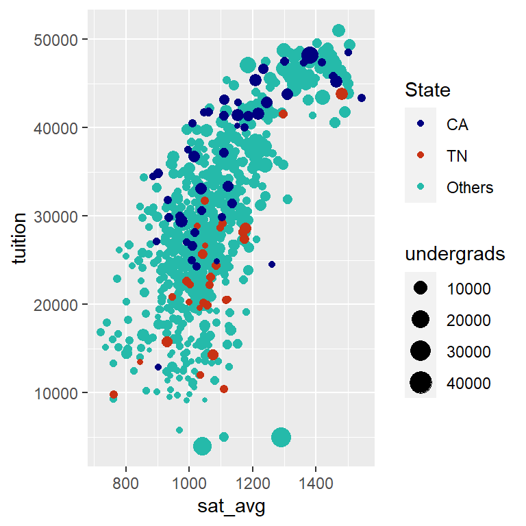

```r
college %>%
  filter(control == "Private") %>%
  mutate(State = ifelse(state == "CA", "CA", ifelse(state == "TN", "TN", "Others"))) %>%
  arrange(factor(State, levels=c("Others", "TN", "CA"))) %>%
  ggplot() +
  geom_point(aes(x = sat_avg, y = tuition, color = State, size = undergrads)) +
  scale_color_manual(breaks = c("CA","TN","Others"),
                     values = c("navyblue",
                                rgb(200, 50, 20, maxColorValue=255),
                                "#25BAAA"))
```

## 3.2 Color Palette

Choosing colors manually is too time consuming especially when you have too many categories. We can rely on the existing color palettes in R, which stores a sequence of pre-specified colors that are suitable for representing continuous and discrete data. There are two main color palettes in R which are the R packages `RcolorBrewer` and `viridis`, displayed as follows.

The `RColorBrewer` package contain following palettes. As we can see, there are three types of palettes: sequential, discrete, and diverging. The **sequential** color palettes can be used for **continuous** variables. The **discrete** color palettes can be used for **discrete** variables. The **diverging** color palettes can be used for **continuous** variables who have **both positive and negative values**, such as correlation. To use the `RColorBrewer` palettes, we use the following three functions depending on the type of variable:

- `scale_colour_distiller()` is a continuous color scale.
- `scale_colour_brewer()` is a discrete color scale.
- `scale_colour_fermenter()` is a binned color scale.

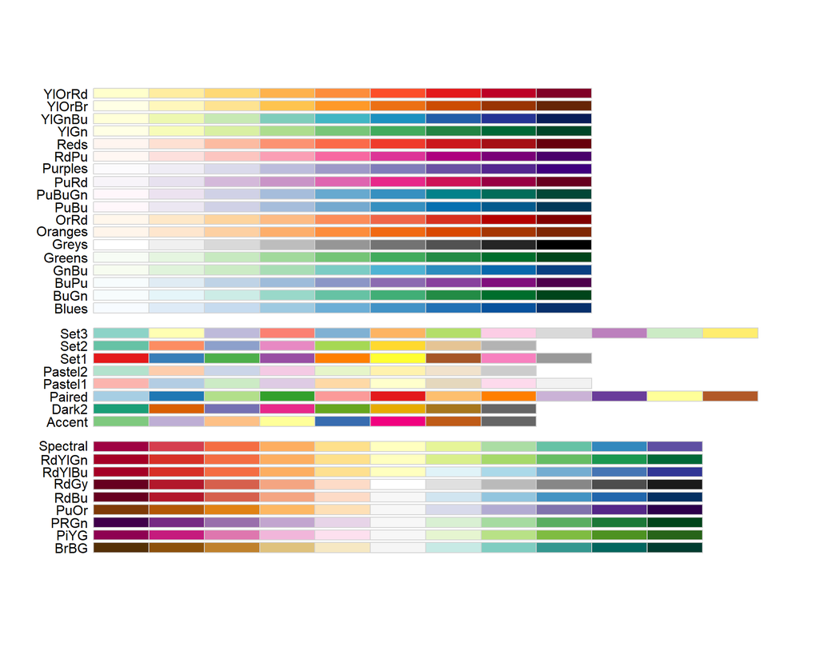

Meanwhile, the `viridis` package contains only four palettes shown below. All these four palettes can be applied to **both continuous and discrete variables**. To use the `viridis` palettes, we use the following three functions depending on the type of variable:

- `scale_fill_viridis_c()` is a continuous color scale.
- `scale_fill_viridis_d()` is a discrete color scale.
- `scale_fill_viridis_b()` is a binned color scale.

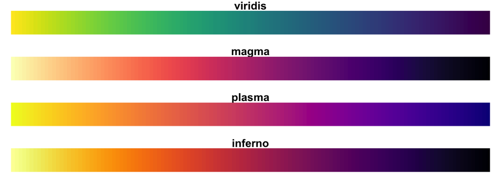